# Practical Machine Learning Course Project : Writeup

## By : Nitin Agarwal

Step 1 : Load the required packages

```r
set.seed(1234)
library(corrplot)
library(nnet)
library(caret)
```

Step 2 : Load the training dataset

```r
alldata<-read.csv("/home/nitin/Downloads/pml-training.csv")
```

Step 3 : View the summary of data to get idea about the data

```r
summary(alldata)
```

```
## X user_name raw_timestamp_part_1 raw_timestamp_part_2
## Min. : 1 adelmo :3892 Min. :1.32e+09 Min. : 294
## 1st Qu.: 4906 carlitos:3112 1st Qu.:1.32e+09 1st Qu.:252912
## Median : 9812 charles :3536 Median :1.32e+09 Median :496380
## Mean : 9812 eurico :3070 Mean :1.32e+09 Mean :500656
## 3rd Qu.:14717 jeremy :3402 3rd Qu.:1.32e+09 3rd Qu.:751891
## Max. :19622 pedro :2610 Max. :1.32e+09 Max. :998801
##
## cvtd_timestamp new_window num_window roll_belt
## 28/11/2011 14:14: 1498 no :19216 Min. : 1 Min. :-28.9
## 05/12/2011 11:24: 1497 yes: 406 1st Qu.:222 1st Qu.: 1.1
## 30/11/2011 17:11: 1440 Median :424 Median :113.0
## 05/12/2011 11:25: 1425 Mean :431 Mean : 64.4
## 02/12/2011 14:57: 1380 3rd Qu.:644 3rd Qu.:123.0
## 02/12/2011 13:34: 1375 Max. :864 Max. :162.0
## (Other) :11007
## pitch_belt yaw_belt total_accel_belt kurtosis_roll_belt
## Min. :-55.80 Min. :-180.0 Min. : 0.0 :19216
## 1st Qu.: 1.76 1st Qu.: -88.3 1st Qu.: 3.0 #DIV/0! : 10
## Median : 5.28 Median : -13.0 Median :17.0 -1.908453: 2
## Mean : 0.31 Mean : -11.2 Mean :11.3 0.000673 : 1
## 3rd Qu.: 14.90 3rd Qu.: 12.9 3rd Qu.:18.0 0.005503 : 1
## Max. : 60.30 Max. : 179.0 Max. :29.0 -0.016850: 1
## (Other) : 391
## kurtosis_picth_belt kurtosis_yaw_belt skewness_roll_belt
## :19216 :19216 :19216
## #DIV/0! : 32 #DIV/0!: 406 #DIV/0! : 9
## 47.000000: 4 0.000000 : 4
## -0.150950: 3 0.422463 : 2
## -0.684748: 3 0.000748 : 1
## 11.094417: 3 -0.003095: 1
## (Other) : 361 (Other) : 389
## skewness_roll_belt.1 skewness_yaw_belt max_roll_belt max_picth_belt
## :19216 :19216 Min. :-94 Min. : 3
## #DIV/0! : 32 #DIV/0!: 406 1st Qu.:-88 1st Qu.: 5
## 0.000000 : 4 Median : -5 Median :18
## -2.156553: 3 Mean : -7 Mean :13
## -3.072669: 3 3rd Qu.: 18 3rd Qu.:19
## -6.324555: 3 Max. :180 Max. :30
## (Other) : 361 NA's :19216 NA's :19216
```

[output cut: 289 more lines]

```
## Min. : -8.09 Min. :-498.0 Min. :-632 Min. :-446.0
## 1st Qu.: -0.18 1st Qu.:-178.0 1st Qu.: 57 1st Qu.:-182.0
## Median : 0.08 Median : -57.0 Median : 201 Median : -39.0
## Mean : 0.15 Mean : -61.7 Mean : 164 Mean : -55.3
## 3rd Qu.: 0.49 3rd Qu.: 76.0 3rd Qu.: 312 3rd Qu.: 26.0
## Max. :231.00 Max. : 477.0 Max. : 923 Max. : 291.0
##
## magnet_forearm_x magnet_forearm_y magnet_forearm_z classe
## Min. :-1280 Min. :-896 Min. :-973 A:5580
## 1st Qu.: -616 1st Qu.: 2 1st Qu.: 191 B:3797
## Median : -378 Median : 591 Median : 511 C:3422
## Mean : -313 Mean : 380 Mean : 394 D:3216
## 3rd Qu.: -73 3rd Qu.: 737 3rd Qu.: 653 E:3607
## Max. : 672 Max. :1480 Max. :1090
##
```

From the above summary results we can see that their are lot of columns with many NA's. (eg. NA's 19216) and are Non Numeric (with #DIV/0!) Also many of the columns are non numeric.

Step 4 : Remove all the columns with NA's.

```r
name <- names(alldata)
col<-name[c(8:160)];
colsNA <- c("max_roll_belt","max_picth_belt","min_roll_belt","min_pitch_belt","amplitude_roll_belt","amplitude_pitch_belt","var_total_accel_belt",
            "avg_roll_belt","stddev_roll_belt","var_roll_belt","avg_pitch_belt","stddev_pitch_belt","var_pitch_belt","avg_yaw_belt","stddev_yaw_belt",
            "var_yaw_belt","var_accel_arm","avg_roll_arm","stddev_roll_arm","var_roll_arm","avg_pitch_arm","stddev_pitch_arm","var_pitch_arm","avg_yaw_arm",
            "stddev_yaw_arm","var_yaw_arm","max_roll_arm","max_picth_arm","max_yaw_arm","min_roll_arm","min_pitch_arm","min_yaw_arm","amplitude_roll_arm",
            "amplitude_pitch_arm","amplitude_yaw_arm","max_roll_dumbbell","max_picth_dumbbell","min_roll_dumbbell","min_pitch_dumbbell","amplitude_roll_dumbbell","amplitude_pitch_dumbbell",
            "var_accel_dumbbell","avg_roll_dumbbell","stddev_roll_dumbbell","var_roll_dumbbell","avg_pitch_dumbbell","stddev_pitch_dumbbell","var_pitch_dumbbell",
            "avg_yaw_dumbbell","stddev_yaw_dumbbell","var_yaw_dumbbell","max_roll_forearm","max_picth_forearm","min_roll_forearm","min_pitch_forearm","amplitude_roll_forearm",
            "amplitude_pitch_forearm","var_accel_forearm","avg_roll_forearm","stddev_roll_forearm","var_roll_forearm","avg_pitch_forearm","stddev_pitch_forearm",
            "var_pitch_forearm","avg_yaw_forearm","stddev_yaw_forearm","var_yaw_forearm")

col <- setdiff(col,colsNA)
tempdata <- alldata[col]
```

Step 5 : Next we try to find the correlation between different features and plot the relationship

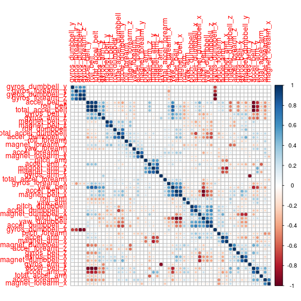

```r
#scale all the features
tempdata.scale<- scale(tempdata[sapply(tempdata, is.numeric)],center=TRUE,scale=TRUE);

#compute the correlation matrix
corMatMy <- cor(tempdata.scale)

#visualize the matrix, clustering features by correlation index.
corrplot(corMatMy, order = "hclust")
```

Step 6 : Add the output variable “classe” to the tempdata and remove Non-Numeric columns

```r
tempdata<-tempdata[sapply(tempdata, is.numeric)] ## Removes Non-Numeric columns
classe <- alldata[,"classe"]
tempdata <- cbind.data.frame(tempdata,classe)
```

Step 7 : Partition the data into training set(75%) and testing set(25%)

```r
inTrain = createDataPartition(tempdata$classe, p = 3/4)[[1]]
training = tempdata[ inTrain,]
testing = tempdata[-inTrain,]
```

Step 8 : Since the number of features is large and their is high correlation between features, we use PCA to reduce the dimension of data. Here 53 is the output column, pcaComp = number of principal components

```r
preprocess <- preProcess(training[,-53],method="pca",pcaComp=30)
trainpc <- predict(preprocess,training[,-53])
```

Step 9 : Now train the data using the principal components obtained in previous step. We are using Random Forest method for training.

```r
fit<-train(training$classe~.,method="rf",data=trainpc)
```

Step 10 : Once you have trained the model. Now use the model to make predictions on testing set.

```r
testpc <- predict(preprocess,testing[,-53])
predictions <- predict(fit,testpc)
```

Step 11 : Now use the confusion matrix to test the accuracy of your model on testing set.

```r
confusionMatrix(testing$classe,predictions)
```

```
## Confusion Matrix and Statistics
##
## Reference
## Prediction A B C D E
## A 1388 2 3 2 0
## B 17 926 6 0 0
## C 3 17 826 8 1
## D 1 1 31 770 1
## E 0 4 6 3 888
##
## Overall Statistics
##
## Accuracy : 0.978
## 95% CI : (0.974, 0.982)
## No Information Rate : 0.287
## P-Value [Acc > NIR] : <2e-16
##
## Kappa : 0.973
## Mcnemar's Test P-Value : NA
##
## Statistics by Class:
##
## Class: A Class: B Class: C Class: D Class: E
## Sensitivity 0.985 0.975 0.947 0.983 0.998
## Specificity 0.998 0.994 0.993 0.992 0.997
## Pos Pred Value 0.995 0.976 0.966 0.958 0.986
## Neg Pred Value 0.994 0.994 0.989 0.997 1.000
## Prevalence 0.287 0.194 0.178 0.160 0.181
## Detection Rate 0.283 0.189 0.168 0.157 0.181
## Detection Prevalence 0.284 0.194 0.174 0.164 0.184
## Balanced Accuracy 0.992 0.984 0.970 0.988 0.997
```

From the confusion matrix we can see that our model is 97.8% accurate on the testing set. So, it seems a quite good fit for our data, As most of the test samples are correctly classified.